# Predicting New-User Activity in the Next Month

### Zindi "New User Engagement" challenge · AI7101 final project

**Goal:** from what a user does in their *signup month*, predict whether they will be **active the following month**.

## 1 · Problem and why it matters

- A platform (competitions, blogs, jobs, discussions) acquires thousands of new users, but **most never come back**: only ~20 % of signups are active in month 2.
- Re-engagement (emails, push, mentor / onboarding offers) is **costly and must be targeted**.
- **ML model → ranks new users by churn risk** one month ahead:
  - spend the retention budget on users who *can* be won,
  - cut wasted messages (cost), raise activation (quality),
  - learn which first-month behaviours drive retention.

**Task type:** binary classification, imbalanced (~1 : 4), scored by F1 on class 1.

## 2 · Loading data and splitting into X / y

```python
raw = load_raw(exclude_titles=())          # pd.read_csv of every table, unchanged
raw.shapes().T
```

|  | users | activity | participation | discussions | comments | competitions | blogs | jobs | sample_submission |
| --- | --- | --- | --- | --- | --- | --- | --- | --- | --- |
| rows | 12413 | 317292 | 8385 | 1439 | 467 | 247 | 117 | 34 | 1340 |
| columns | 8 | 6 | 8 | 9 | 6 | 20 | 6 | 7 | 2 |

```python
spec = DatasetSpec(feature_groups=("profile", "activity_counts"))
xy_raw = build_xy(raw, spec)                                  # raw labels, per-page features
X, y = xy_raw.X[xy_raw.labelled], xy_raw.y[xy_raw.labelled].astype(int)   # labelled = signups Nov..Mar
X_test = test_set(xy_raw, raw)                                # April signups (hidden labels)
print(f"X: {X.shape}   y: {y.shape}   test (April cohort): {X_test.shape}")
X.iloc[:3, :8]
```

```
X: (9026, 391)   y: (9026,)   test (April cohort): (1340, 391)
```

| User_ID | t | FeatureX | FeatureY | Countries_ID | signup_day | signup_hour | act_create_alias | act_identify | act_Accepted_Team_Leadership_Transfer |
| --- | --- | --- | --- | --- | --- | --- | --- | --- | --- |
| ID_DC6S4E9O | 2 | 0 | 0 | X9GR | 16 | 19 | 1 | 1 | 0 |
| ID_E8S97OUT | 1 | 1 | 0 | X9GR | 27 | 22 | 1 | 2 | 0 |
| ID_QZ1HASL3 | 2 | 0 | 0 | X9GR | 1 | 23 | 1 | 1 | 0 |

## 3 · Data preparation (each step has a reason)

| Step | What | Why |
| --- | --- | --- |
| **Target** | `y = 1` if the user has *any* event (click, join, post, comment) in month *t+1* | Competition definition; 4 tables merged into 1 binary target |
| **Label availability** | M4 hidden (test), M5 has no next month → train on **9,026** users (M11–M3) | No leakage; only observable labels |
| **Features** | signup-month **event counts per activity** (0 if never done) | Behaviour is the only signal; zero-fill = "did not do it" |
| **Categorical** | `FeatureX/Y`, `Countries_ID` → pandas category → one-hot (LogReg) / ordinal code (tree) | Models need numbers; unseen country → ignored / −1 |
| **Missing** | `Countries_ID` missing for 47 % of users (39 % of labelled) → separate "unknown" category, not dropped | Missingness may carry signal; dropping loses half the users |
| **New features** | `signup_hour`, `signup_day` from timestamp; **page → page-type** counts (`comp_page`, `blog_page`, `job_page`) | Specific pages change every month → generalise to new months (shown later) |
| **Scaling** | `StandardScaler` for LogReg only | Counts are heavy-tailed; trees do not need it |

```
Missing Countries_ID: 38.9%
Positive rate (raw labels): 30.5%
```

|  | count | mean | std | min | 25% | 50% | 75% | max |
| --- | --- | --- | --- | --- | --- | --- | --- | --- |
| signup_day | 9026.0 | 16.74 | 9.41 | 1.0 | 8.0 | 18.0 | 26.0 | 31.0 |
| signup_hour | 9026.0 | 11.94 | 5.36 | 0.0 | 8.0 | 12.0 | 16.0 | 23.0 |
| act_Viewed_All_Competitions | 9026.0 | 3.50 | 6.54 | 0.0 | 1.0 | 1.0 | 4.0 | 167.0 |
| act_Viewed_All_Discussions | 9026.0 | 2.89 | 5.62 | 0.0 | 1.0 | 1.0 | 3.0 | 289.0 |
| act_Viewed_All_Learning_Pages | 9026.0 | 1.61 | 2.19 | 0.0 | 1.0 | 1.0 | 2.0 | 74.0 |
| act_Downloaded_Competition_Datafile | 9026.0 | 1.20 | 3.74 | 0.0 | 0.0 | 0.0 | 0.0 | 136.0 |

## 4 · EDA (1): the labels do not look right

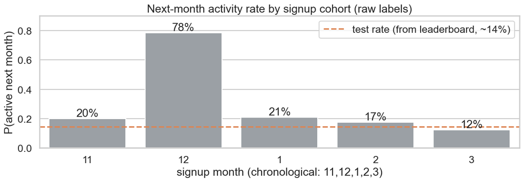

- M12 signups: **78 %** active vs 12–21 % elsewhere → all-ones F1 was 0.47 in CV but **0.25 on the leaderboard**.
- Something in M12's *label month* inflates the label.

## 4 · EDA (2): one system event poisons the target

```
badge_OCZE: 8,864 rows, 8,489 users
Day-of-month distribution of badge_OCZE (top):
datetime Day_of_month
15    3219
29     287
4      250
```

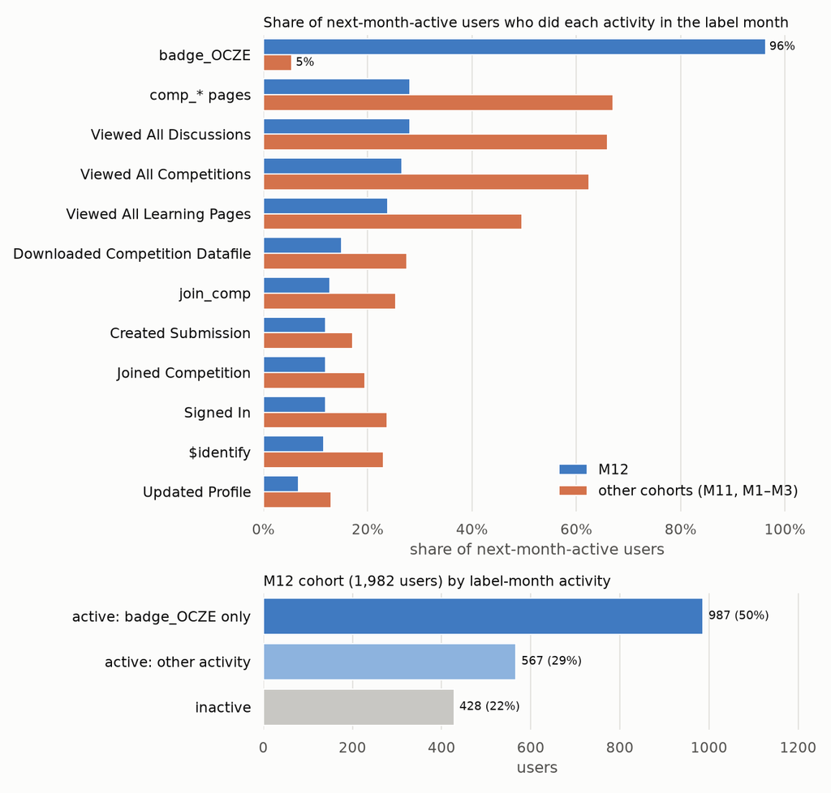

## 4 · EDA (3): fix, verify, and re-check class balance

```
All-ones F1 implied by positive rate: raw 0.468 -> clean 0.328  (leaderboard: 0.25)
```

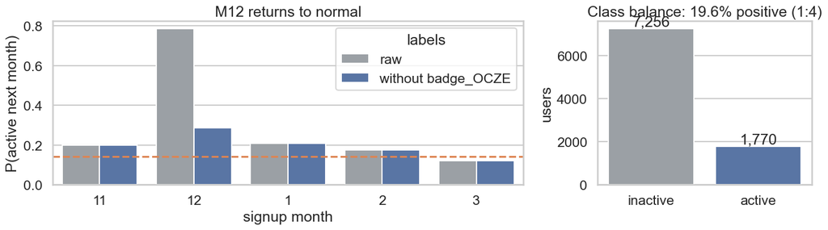

## 4 · EDA (4): which behaviours predict retention?

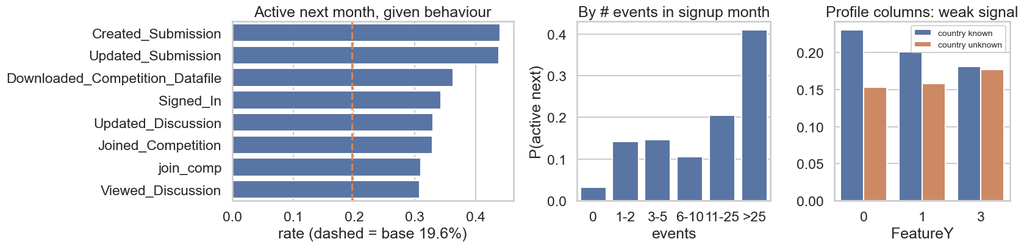

**Findings:** activity volume is the strongest signal (heavy users >25 events: 41 % vs 3 % with none); profile columns and missing country barely matter → keep them, but rely on behaviour counts.

## 4 · EDA (5): per-page features do not transfer to new months

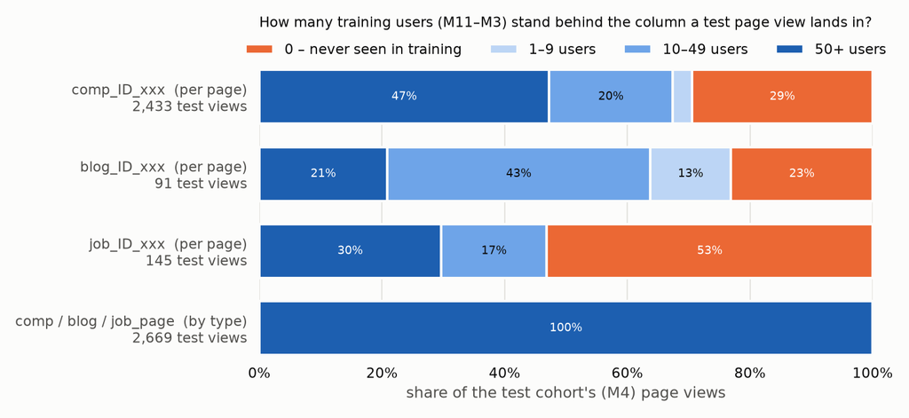

```
per-page features: 390 columns  ->  per-type features: 45 columns
```

## 5 · Evaluation design

- **Metric: F1 of the positive class** – the competition metric; with 1 : 4 imbalance, accuracy would reward "everyone inactive". Reference = all-ones (F1 = 2p/(1+p) = **0.328**).
- **Cross-validation:** 5-fold, **stratified by label, grouped by user**, one fixed seed → every model sees the *same* folds.
- **Hyper-parameters:** grid of **216** decision-tree settings (depth, leaf size, criterion, class weight), scored by F1.
- **Nested CV:** the grid search runs *inside* each outer training fold, so the validation score is not inflated by tuning.
- Threshold fixed at 0.5 (no tuning) so experiments are comparable.

```python
folds = kfold_by_user(xy, 5)
print(pd.DataFrame({"fold": [f.k for f in folds],
                    "n_valid": [len(f.valid_index) for f in folds],
                    "pos_rate": [xy.y.loc[f.valid_index].mean() for f in folds]}).round(3).to_string(index=False))
```

```
 fold  n_valid  pos_rate
    0     1806     0.203
    1     1805     0.193
    2     1805     0.200
    3     1805     0.203
    4     1805     0.182
```

## 6 · Models, tuning and results

[output not shown]

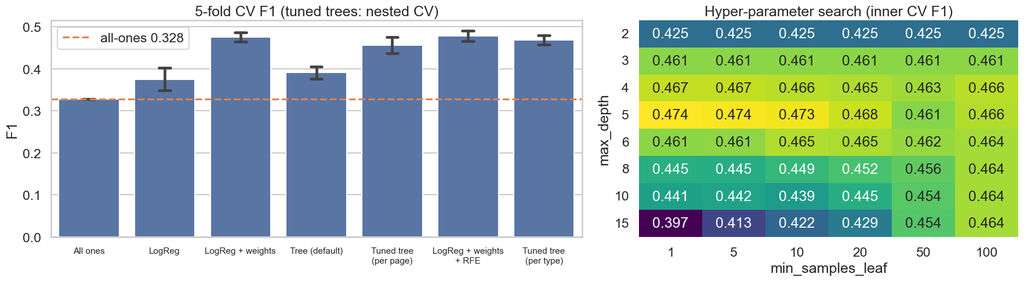

## 7 · Analysis, real-world use and impact

```
Base rate 19.6%. LogReg+weights: flags 31%, precision 39% (lift x2.0), recall 61%
Nudge everyone      :  10000 msgs, $ 10000, actives reached  1961, $5.10 per active
Nudge model's picks :   3070 msgs, $  3070, actives reached  1194, $2.57 per active
```

**Takeaways**

**Does it solve the problem?** Partly: it ranks users usefully, but absolute accuracy is modest; a month of signup behaviour is a limited signal.

**Limitations / next:** random-split CV mixes months → use time-based CV; tune the threshold; add richer features; confirm on the leaderboard.

# Thank you — Questions?

Code: `src/` (data, eval, models) · Report: `report/report.pdf` · Reproduce: `python scripts/run_cv.py`